# hw3

## Monthly Seasonality Analysis

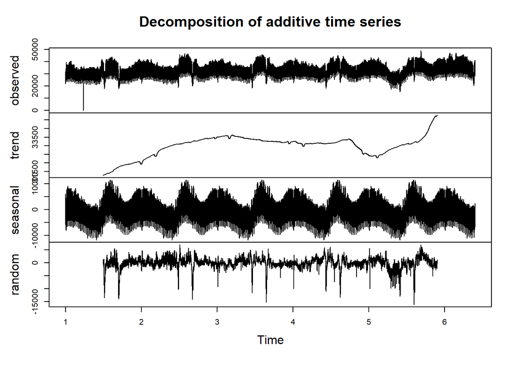

```r
ts_month=ts(consumptiondata$Consumption,frequency = 24*7*52)
Monthly_additive=decompose(ts_month, type = "add")
plot(Monthly_additive)
```

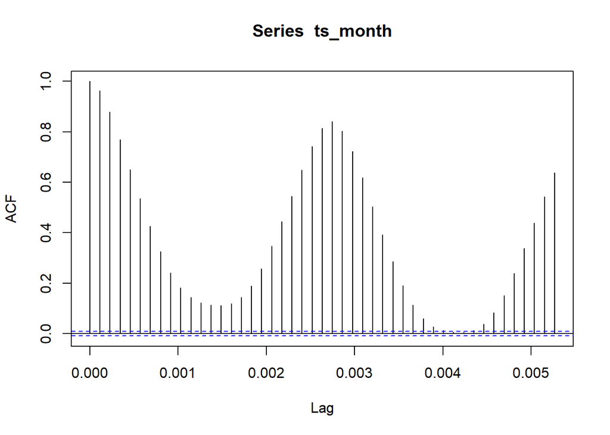

```r
acf(ts_month,na.action=na.pass)
```

Different seasonality values are investigated during the study. Clearly the seasonality on a weekly basis is the most significant one. To construct our model I choose the frequency as 168.

# Modelling

## Deseasonalize and Detrend

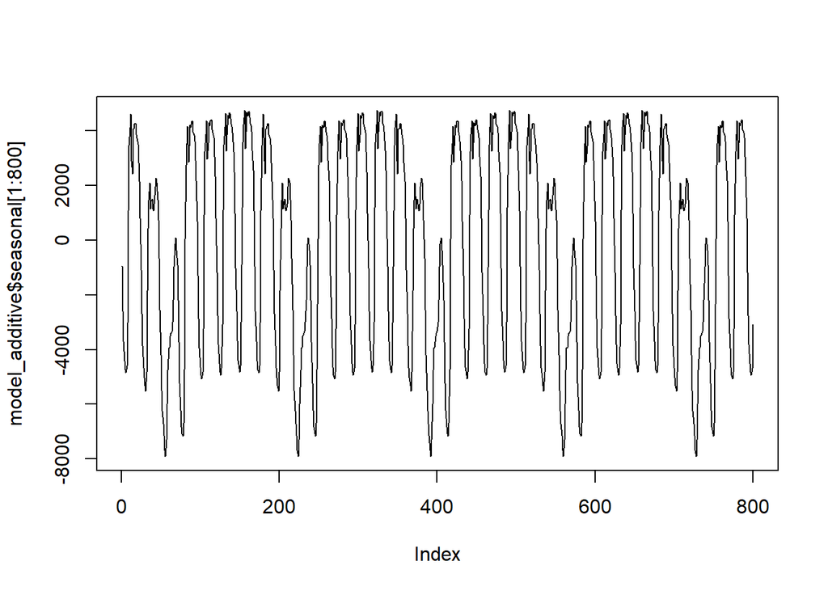

```r
model<-ts(ts_week,start(2016,1),frequency = 168)
model_additive<-decompose(model, type = "additive")
plot(model_additive$seasonal[1:800], type='l')
```

Here the time series object is decomposed additively with the frequency of 168.

```r
summary(ur.kpss(model_additive$random))
```

```
##
## #######################
## # KPSS Unit Root Test #
## #######################
##
## Test is of type: mu with 18 lags.
##
## Value of test-statistic is: 0.0042
##
## Critical value for a significance level of:
##                 10pct  5pct 2.5pct  1pct
## critical values 0.347 0.463  0.574 0.739
```

This data is sufficient to build our model around. Random component’s stationary condition is satisfied since it’s test-statistic value is lower than the critical values.

### Deseasonalization

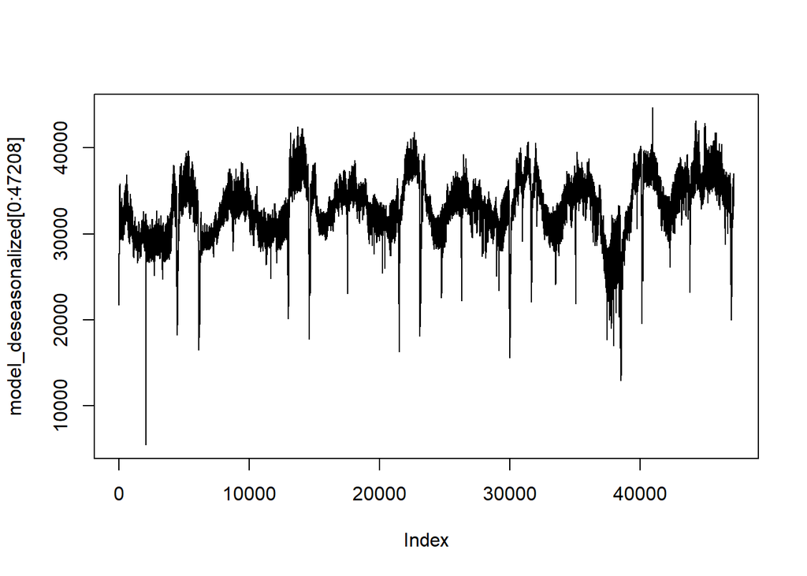

```r
model_deseasonalized<-model-model_additive$seasonal
plot(model_deseasonalized[0:47208], type = 'l')
```

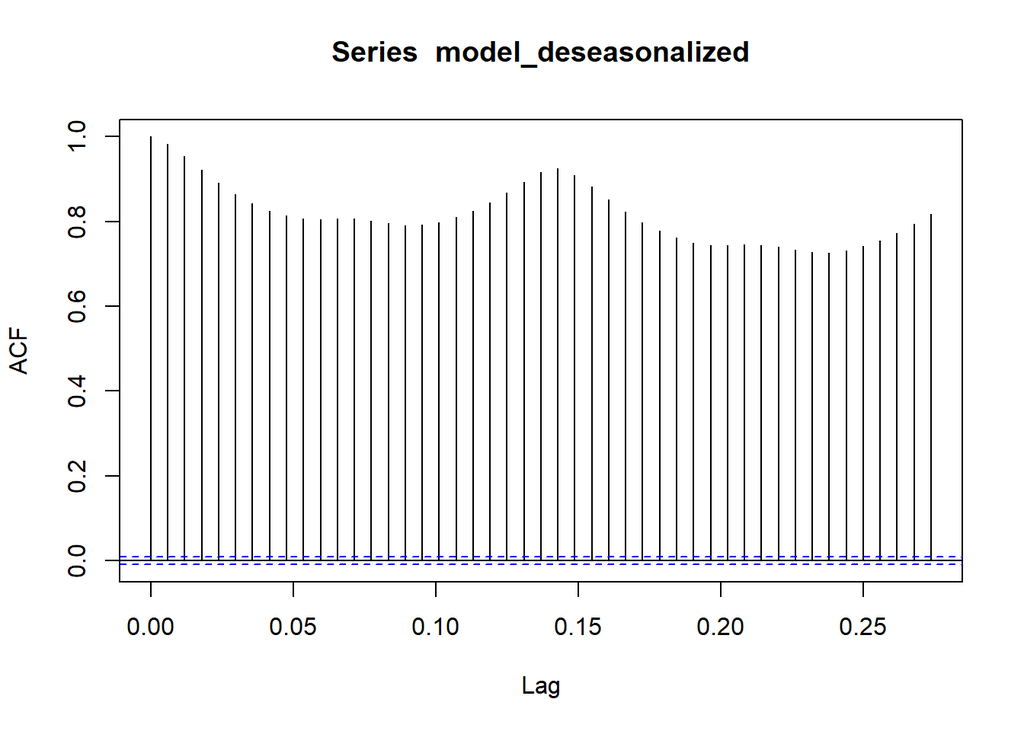

```r
acf(model_deseasonalized, na.action = na.pass)
```

It still seems correlated since we do not remove the yearly seasonality. Trend component is still inside the model next step is to eliminate it.

### Detrendation

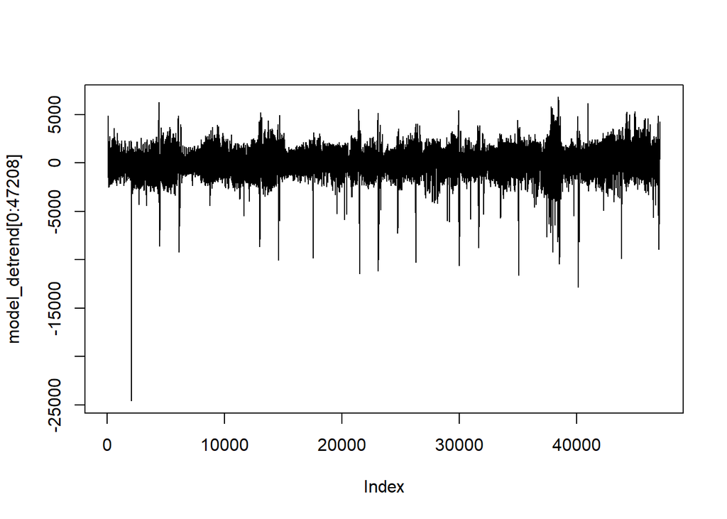

```r
model_detrend<-model_deseasonalized-model_additive$trend
plot(model_detrend[0:47208], type = 'l')
```

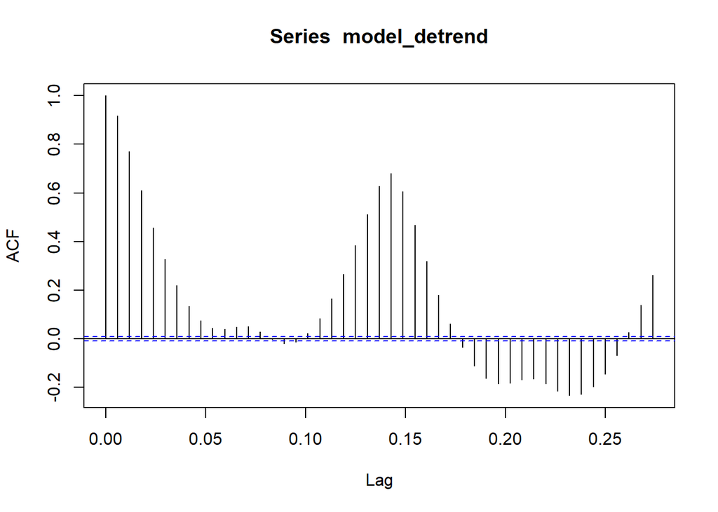

```r
acf(model_detrend,na.action = na.pass)
```

We can see that there are lots of outlier points in our data from the plot. ACF values are getting lower which is what we want. It still can be better but the next step is to build AR & MA models therefore, we can continue to build our models using this data.

##AR & MA Models

### AR Models

```r
Model1<-arima(model_additive$random, order=c(1,0,0))

Model2<-arima(model_additive$random, order=c(2,0,0))

Model3<-arima(model_additive$random, order=c(3,0,0))

Model4<-arima(model_additive$random, order=c(4,0,0))

Model5<-arima(model_additive$random, order=c(5,0,0))

Model6<-arima(model_additive$random, order=c(6,0,0))

Model7<-arima(model_additive$random, order=c(7,0,0))
```

AR models are constructed now with the p values of 1:7. Now I check to see which model’s AIC value is the lowest.

```r
AIC(Model1)
```

```
## [1] 733654.4
```

```r
AIC(Model2)
```

```
## [1] 722906
```

```r
AIC(Model3)
```

```
## [1] 722896.7
```

```r
AIC(Model4)
```

```
## [1] 722855.1
```

```r
AIC(Model5)
```

```
## [1] 722855.1
```

```r
AIC(Model6)
```

```
## [1] 722806.9
```

```r
AIC(Model7)
```

```
## [1] 722808.4
```

The lowest value is 722806.9 of Model6. I choose the sixth model to build ARIMA models. Now checking on the MA models.

### MA Models

```r
Model1<-arima(model_additive$random, order=c(0,0,1))

Model2<-arima(model_additive$random, order=c(0,0,2))

Model3<-arima(model_additive$random, order=c(0,0,3))

Model4<-arima(model_additive$random, order=c(0,0,4))

Model5<-arima(model_additive$random, order=c(0,0,5))

Model6<-arima(model_additive$random, order=c(0,0,6))

Model7<-arima(model_additive$random, order=c(0,0,7))
```

MA models are constructed now with the q values of 1:7. Now I check to see which model’s AIC value is the lowest.

```r
AIC(Model1)
```

```
## [1] 771819.8
```

```r
AIC(Model2)
```

```
## [1] 747445.1
```

```r
AIC(Model3)
```

```
## [1] 734563
```

```r
AIC(Model4)
```

```
## [1] 728972.5
```

```r
AIC(Model5)
```

```
## [1] 725530.1
```

```r
AIC(Model6)
```

```
## [1] 724500.2
```

```r
AIC(Model7)
```

```
## [1] 723741.9
```

AIC values will go low as their q values getting higher and it will cause a complex model to build. I will select the fifth model since after that the magnitude of the decreases are not as high as before.

### AR & MA Model

```r
Model_Final<-arima(model_additive$random, order=c(6,0,5))
AIC(Model_Final)
```

```
## [1] 722803.7
```

As expected the Model_Final resulted the lowest AIC value. We can fit our model ob that.

### Model Fitting

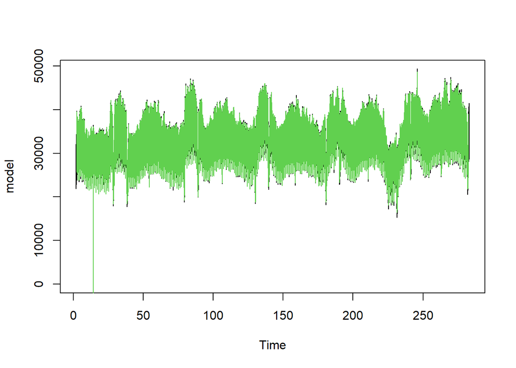

```r
Fitted<-model_additive$random-Model_Final$residuals
modeltransformed<-Fitted+model_additive$seasonal+model_additive$trend

plot(model, type ='l')
points(modeltransformed,type='l', col = 3)
```

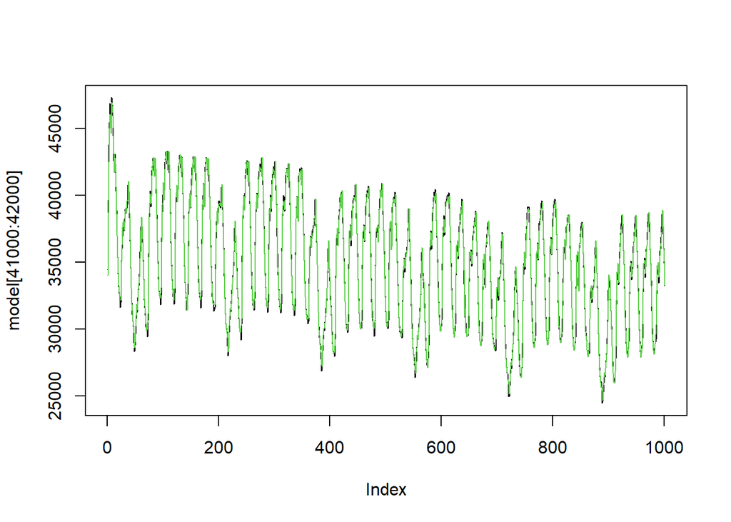

```r
plot(model[41000:42000], type ='l')
points(modeltransformed[41000:42000],type='l', col = 3)
```

It fits our model and even it get some outlier points.

# Forecasting

```r
consumptiondata[,fitted:=modeltransformed]
consumptiondata$fitted[1:100]
```

```
##   [1]       NA       NA       NA       NA       NA       NA       NA       NA
##   [9]       NA       NA       NA       NA       NA       NA       NA       NA
##  [17]       NA       NA       NA       NA       NA       NA       NA       NA
##  [25]       NA       NA       NA       NA       NA       NA       NA       NA
##  [33]       NA       NA       NA       NA       NA       NA       NA       NA
##  [41]       NA       NA       NA       NA       NA       NA       NA       NA
##  [49]       NA       NA       NA       NA       NA       NA       NA       NA
##  [57]       NA       NA       NA       NA       NA       NA       NA       NA
##  [65]       NA       NA       NA       NA       NA       NA       NA       NA
##  [73]       NA       NA       NA       NA       NA       NA       NA       NA
##  [81]       NA       NA       NA       NA 36775.57 38705.43 39579.04 38866.61
##  [89] 38787.96 39369.16 38634.16 36472.29 34905.98 34069.47 33170.51 32313.96
##  [97] 29566.24 27548.70 26640.16 25714.47
```

The first 84 value is listed as NA and we have to get rid of them.

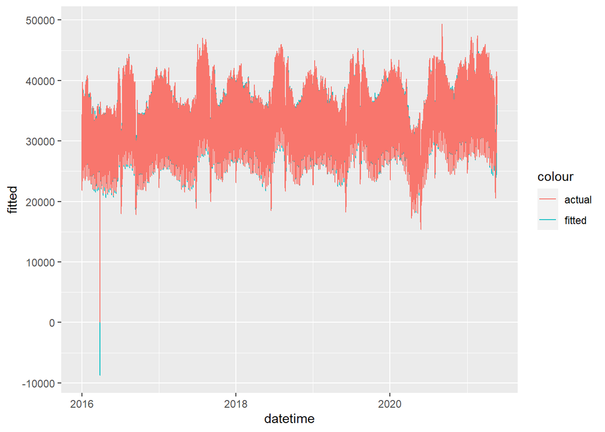

```r
res_fit = residuals((Model_Final))
consumptiondata[,fit_res:=res_fit]

na_84=mean(consumptiondata$fitted[85:168])
na_84_res=mean(consumptiondata$fit_res[85:168])

consumptiondata$fitted[1:84]= na_84
consumptiondata$fit_res[1:84]=na_84_res

test_set = consumptiondata[(.N-359):.N]
res_tes=predict(Model_Final,n.ahead = 84)$pred

endtrend_84 = tail(model_additive$trend[!is.na(model_additive$trend)],84)
endseason_84= tail(model_additive$seasonal[!is.na(model_additive$seasonal)],84)

end_comb = res_tes+endtrend_84+endseason_84

consumptiondata$fitted[47125:47208]=end_comb

ggplot(consumptiondata , aes(x=datetime) )  +
  geom_line(aes(y=fitted , col = "fitted")) +
  geom_line(aes(y=Consumption , col="actual"))
```

```r
actual = consumptiondata[datetime<='2020-05-20 23:00' & datetime>='2020-05-06 00:00' , Consumption ]
forecast = consumptiondata[datetime<='2020-05-20 23:00' & datetime>='2020-05-06 00:00' , fitted ]
forecast = as.numeric(forecast)
error = abs(actual - forecast)
percentage=error/consumptiondata[datetime<='2020-05-20 23:00' & datetime>='2020-05-06 00:00' , Consumption ]
wape=(sum(percentage)/360)*100
wape
```

```
## [1] 1.926607
```

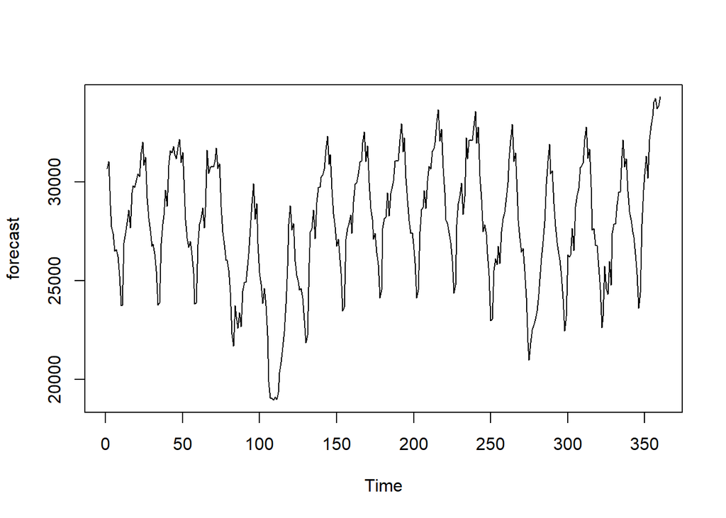

```r
ts.plot(forecast)
```

# Conclusion